# Adding a Categorical Predictor

Lesson 31 — Parallel Slopes and Simpson’s Paradox

Lt Col Cho

## The `penguins` data

```r
library(tidyverse)
library(palmerpenguins)

penguins
```

```
# A tibble: 344 × 8
   species island    bill_length_mm bill_depth_mm flipper_length_mm body_mass_g sex     year
   <fct>   <fct>              <dbl>         <dbl>             <int>       <int> <fct>  <int>
 1 Adelie  Torgersen           39.1          18.7               181        3750 male    2007
 2 Adelie  Torgersen           39.5          17.4               186        3800 female  2007
 3 Adelie  Torgersen           40.3          18                 195        3250 female  2007
 4 Adelie  Torgersen           NA            NA                  NA          NA <NA>    2007
 5 Adelie  Torgersen           36.7          19.3               193        3450 female  2007
 6 Adelie  Torgersen           39.3          20.6               190        3650 male    2007
 7 Adelie  Torgersen           38.9          17.8               181        3625 female  2007
 8 Adelie  Torgersen           39.2          19.6               195        4675 male    2007
 9 Adelie  Torgersen           34.1          18.1               193        3475 <NA>    2007
10 Adelie  Torgersen           42            20.2               190        4250 <NA>    2007
# ℹ 334 more rows
```

## Bill depth and flipper length

- **What is the relationship between bill depth and flipper length?**

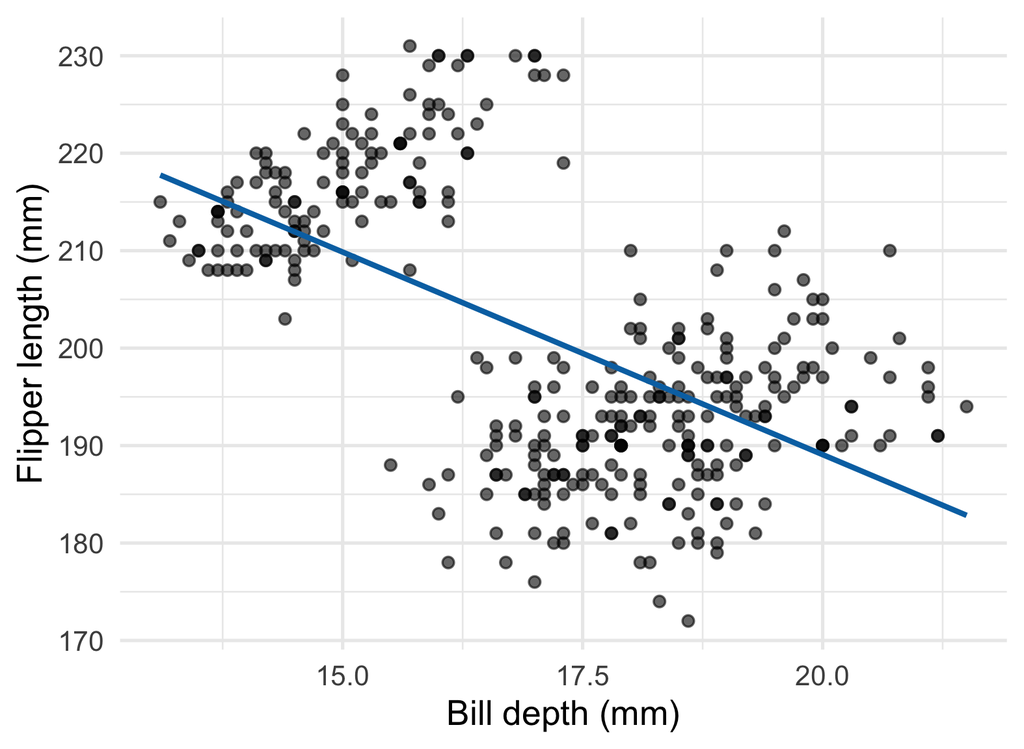

**① Model specification**

$$\text{flipper} = \beta_0 + \beta_1 \times \text{bill depth} + \varepsilon$$

**② Fit the model**

```r
total_mod <- lm(flipper_length_mm ~ bill_depth_mm,
                data = penguins)
coef(total_mod)
```

```
  (Intercept) bill_depth_mm
   272.218987     -4.157371
```

```r
summary(total_mod)$r.squared
```

```
[1] 0.3408822
```

**③ Fitted regression line**

$$\widehat{\text{flipper}} = 272.219 -4.157 \times \text{bill depth}$$

## Flipper length by species

- **What if we want to model the association between species and flipper length?**

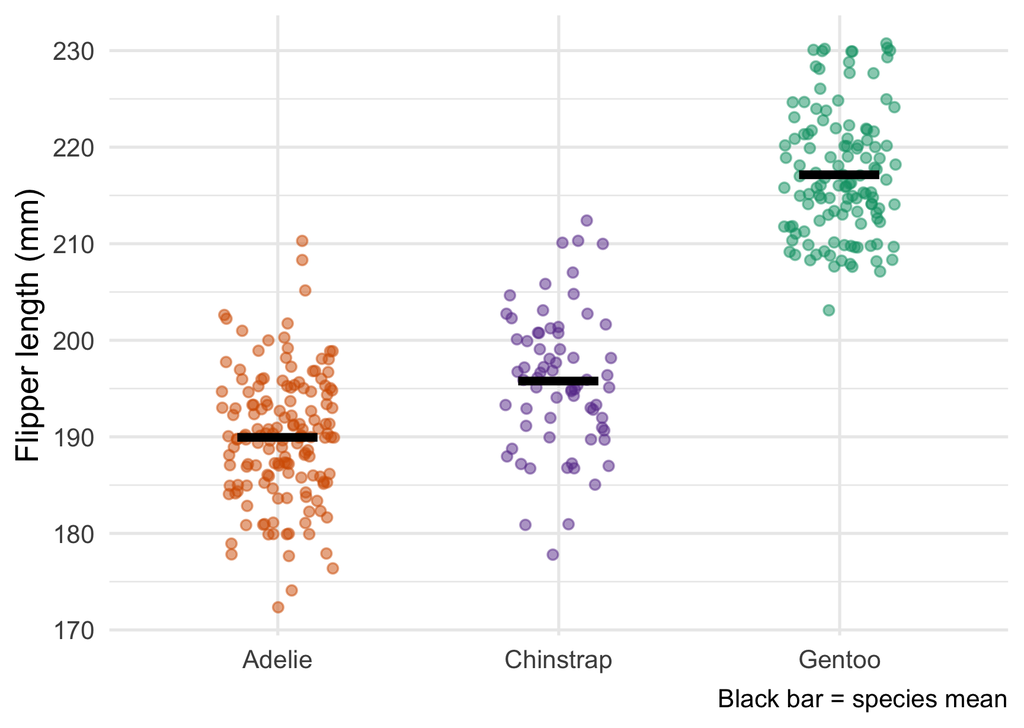

```r
penguins |>
  group_by(species) |>
  summarize(mean_flipper =
              mean(flipper_length_mm,
                   na.rm = TRUE))
```

| Species | n | Mean flipper (mm) |
| --- | --- | --- |
| Adelie | 151 | 189.954 |
| Chinstrap | 68 | 195.824 |
| Gentoo | 123 | 217.187 |

## Indicator variables: two levels

An **indicator variable** equals 1 if an observation is in a given level of a categorical variable and 0 otherwise.

```r
penguins |>
  mutate(sexmale = if_else(sex == "male", 1, 0))
```

| species | flipper_length_mm | sex | sexmale |
| --- | --- | --- | --- |
| Adelie | 181 | male | 1 |
| Adelie | 186 | female | 0 |
| Adelie | 195 | female | 0 |
| Adelie | 193 | female | 0 |
| Adelie | 190 | male | 1 |
| Adelie | 181 | female | 0 |

- `sex` has **2 levels** (female, male), so **1 indicator** is enough: `sexmale` = 1 for a male penguin, 0 for a female penguin.
- **Reference level:** the level with every indicator equal to 0 (here, **female**).

## Indicator variables: more than two levels

```r
penguins |>
  mutate(speciesChinstrap = if_else(species == "Chinstrap", 1, 0),
         speciesGentoo    = if_else(species == "Gentoo", 1, 0))
```

| species | flipper_length_mm | speciesChinstrap | speciesGentoo |
| --- | --- | --- | --- |
| Adelie | 181 | 0 | 0 |
| Adelie | 186 | 0 | 0 |
| Chinstrap | 192 | 1 | 0 |
| Chinstrap | 196 | 1 | 0 |
| Gentoo | 211 | 0 | 1 |
| Gentoo | 230 | 0 | 1 |

- `species` has **3 levels**, so it needs **2 indicators**. In general, a categorical variable with $k$ levels is represented by $k - 1$ indicator variables.
- **Reference level:** Adelie (both indicators equal 0). R uses the first level of the factor: alphabetical order unless the levels are set with `factor()`.
- `lm()` creates these indicator variables automatically when a categorical variable is a predictor.

## A model with `species` as the predictor

**① Model specification**

$$\text{flipper} = \beta_0 + \beta_2 \times \text{speciesChinstrap} + \beta_3 \times \text{speciesGentoo} + \varepsilon$$

**② Fit the model**

```r
species_mod <- lm(flipper_length_mm ~ species, data = penguins)
coef(species_mod)
```

```
     (Intercept) speciesChinstrap    speciesGentoo
      189.953642         5.869887        27.233349
```

**③ Fitted model**

$$\widehat{\text{flipper}} = 189.954 + 5.870 \times \text{speciesChinstrap} + 27.233 \times \text{speciesGentoo}$$

## One equation per species

| Species | Chinstrap | Gentoo | $\widehat{\text{flipper}}$ |
| --- | --- | --- | --- |
| Adelie (reference) | 0 | 0 | $189.954$ |
| Chinstrap | 1 | 0 | $189.954 + 5.870 = 195.824$ |
| Gentoo | 0 | 1 | $189.954 + 27.233 = 217.187$ |

**Numerical predictor**

“For each one-unit increase in $x$, the mean of $y$ changes by $b_1$.”

**Categorical predictor**

“The mean of $y$ for [level] is $b_j$ greater (less) than for the reference level.”

*Chinstrap flippers are 5.870 mm longer than Adelie flippers, on average.*

The fitted values are the species means. Each coefficient compares a level to the **reference level**.

## Color by species

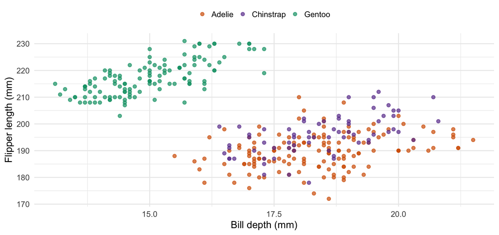

Within each species, penguins with deeper bills have **longer** flippers, on average

## The parallel slopes model

**① Model specification**

$$\text{flipper} = \beta_0 + \beta_1 \times \text{bill depth} + \beta_2 \times \text{speciesChinstrap} + \beta_3 \times \text{speciesGentoo} + \varepsilon$$

**② Fit the model:** `+` adds a predictor; the coefficients are still chosen by least squares.

```r
parallel_mod <- lm(flipper_length_mm ~ bill_depth_mm + species,
                   data = penguins)
coef(parallel_mod)
```

```
     (Intercept)    bill_depth_mm speciesChinstrap    speciesGentoo
      136.948764         2.889123         5.655426        36.953063
```

**③ Fitted model** ($R^2 = 0.831$)

$$\widehat{\text{flipper}} = 136.949 + 2.889 \times \text{bill depth} + 5.655 \times \text{speciesChinstrap} + 36.953 \times \text{speciesGentoo}$$

## Three lines, one slope

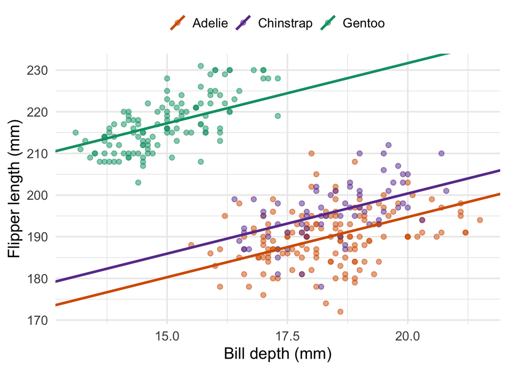

| Species | Intercept | Slope |
| --- | --- | --- |
| Adelie (reference) | $136.949$ | $2.889$ |
| Chinstrap | $136.949 + 5.655 = 142.604$ | $2.889$ |
| Gentoo | $136.949 + 36.953 = 173.902$ | $2.889$ |

The indicators change only the **intercept**; every species has the **same slope**

In R:

```r
library(moderndive)
ggplot(penguins, aes(x = bill_depth_mm,
                     y = flipper_length_mm,
                     color = species)) +
  geom_point() +
  geom_parallel_slopes(se = FALSE)
```

## Interpreting each coefficient

**Bill depth: 2.889**

Among penguins of the **same species**, each additional mm of bill depth is associated with a mean flipper length 2.889 mm longer.

**Chinstrap: 5.655**

Among penguins with the **same bill depth**, Chinstrap flippers are 5.655 mm longer than Adelie flippers, on average.

**Gentoo: 36.953**

Among penguins with the **same bill depth**, Gentoo flippers are 36.953 mm longer than Adelie flippers, on average.

- **“Holding the other predictors constant”** is the general wording for “among penguins of the same species” and “among penguins with the same bill depth”: each coefficient describes a change in one predictor with every other predictor fixed.
- **Intercept (136.949):** the predicted flipper length for an Adelie with a bill depth of 0 mm. This is extrapolation and has no interpretation.
- The species coefficients also changed from the species-only model (5.870 → 5.655; 27.233 → 36.953) because bill depth is now in the model.

## Predictions and residuals

Plug in the bill depth **and** the 0/1 indicators:

| Penguin | Calculation | $\widehat{\text{flipper}}$ |
| --- | --- | --- |
| Adelie, 18 mm | $136.949 + 2.889(18)$ | 188.95 mm |
| Gentoo, 15 mm | $136.949 + 2.889(15) + 36.953$ | 217.24 mm |
| First Gentoo in the data: 13.2 mm, flipper 211 mm | $136.949 + 2.889(13.2) + 36.953$ | 212.04 mm |

$$e = y - \hat{y} = 211 - 212.04 = -1.04 \text{ mm}$$

Negative residual: the model **overestimated** this penguin’s flipper length

## Does adding species help?

| Model | Predictors (k) | R² | Adjusted R² |
| --- | --- | --- | --- |
| flipper ~ bill_depth | 1 | 0.341 | 0.339 |
| flipper ~ species | 2 | 0.778 | 0.777 |
| flipper ~ bill_depth + species | 3 | 0.831 | 0.829 |

The models have different numbers of predictors, so compare **adjusted** $R^2$: bill depth and species together account for the most variation in flipper length

## Two slopes for bill depth

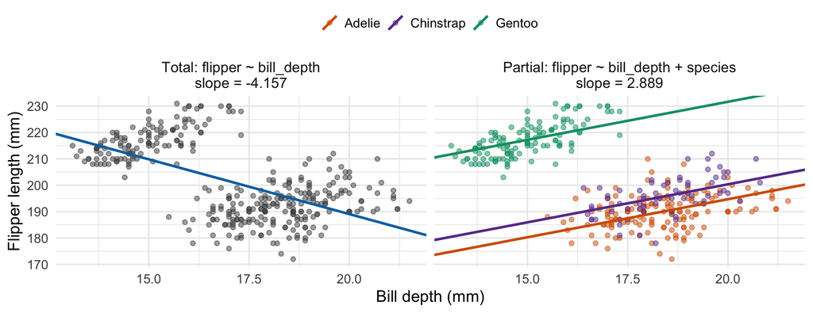

- **Total relationship:** the relationship between $x$ and $y$ in a model with $x$ as the only predictor.
- **Partial relationship:** the relationship between $x$ and $y$ in a model that also includes other predictors, i.e., holding those predictors constant.

## Why the slopes differ

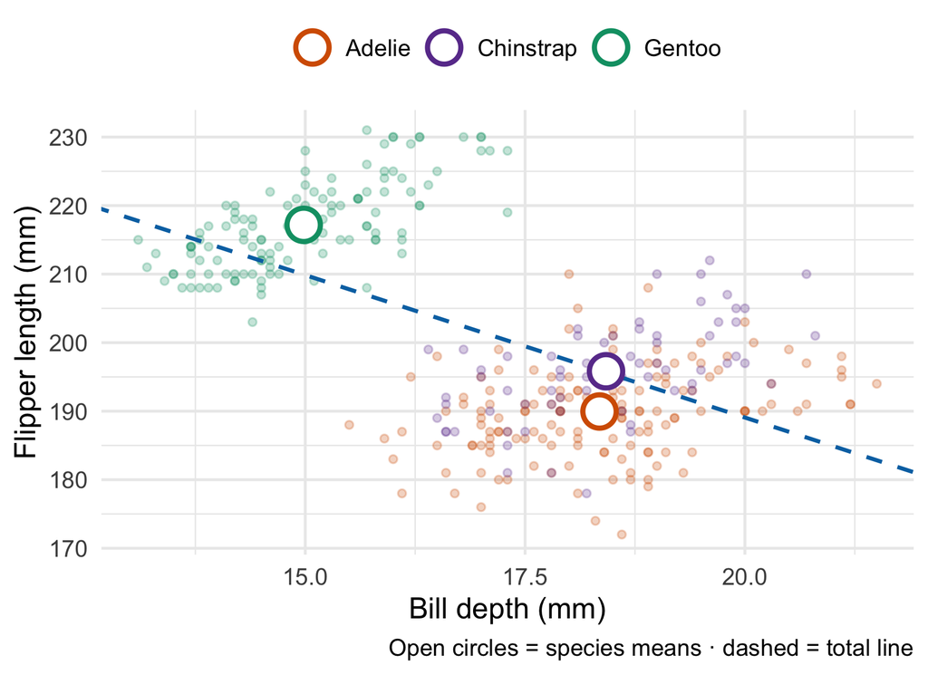

| Species | Mean bill depth | Mean flipper |
| --- | --- | --- |
| Adelie | 18.3 | 190.0 |
| Chinstrap | 18.4 | 195.8 |
| Gentoo | 15.0 | 217.2 |

- Species is associated with **both** bill depth and flipper length.
- Gentoo penguins have the smallest mean bill depth and the largest mean flipper length.
- The total line is determined largely by the differences **between** species; the partial slope compares penguins **within** a species.

When a third variable is associated with both $x$ and $y$, the total and partial relationships can differ in size or direction

## Simpson’s paradox

**Definition (IMS §3.2):** an association between two variables in one direction **reverses** when a third variable is considered.

**In this course,** Simpson’s paradox refers to any **substantial change** in the relationship between two variables when a third variable is introduced:

| Change | Total → partial | Penguins? |
| --- | --- | --- |
| **Reverses direction** | positive ↔︎ negative | ✓ bill depth: -4.157 → +2.889 |
| **Disappears** | a clear relationship → approximately none |  |
| **Changes greatly in magnitude** | e.g., slightly positive → strongly positive | ✓ Gentoo vs. Adelie: +27.233 → +36.953 |

It occurs when the groups defined by the third variable differ in their typical values of $x$ and $y$

## When should the third variable be included?

- **Include it** when it is associated with both $x$ and $y$: without it, the slope for $x$ combines the within-group relationship with the differences between groups.
- **Check the fit:** adjusted $R^2$ rose from 0.339 to 0.829 when species was added.
- **Match the question:**
  - “How does flipper length change with bill depth for penguins of a given species?” → partial relationship
  - “Among all penguins in these data, do deeper bills go with shorter flippers?” → total relationship
- **Association, not causation:** “holding species constant” describes the fitted model. It is not an experiment, and variables not in the model can still change the partial slope.

## Separate lines for each species

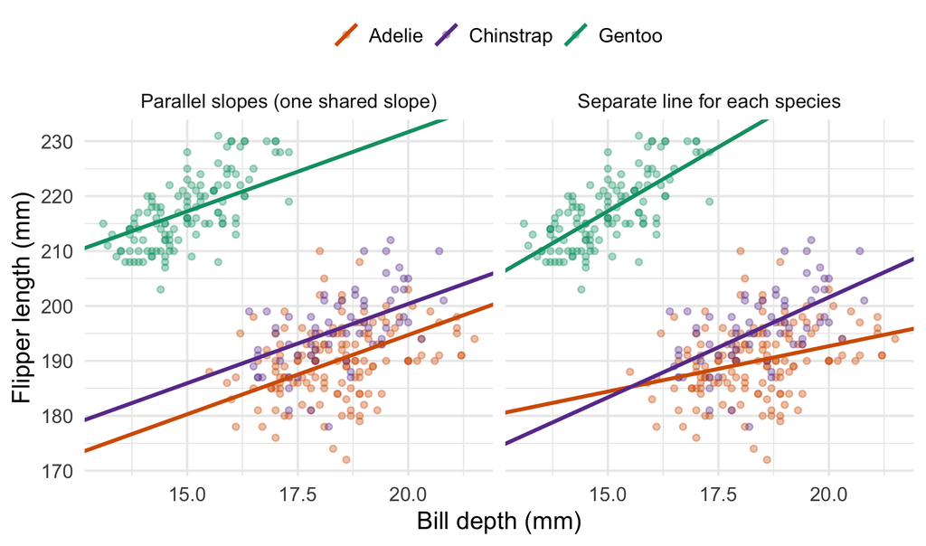

| Model | Slope |
| --- | --- |
| Adelie | 1.65 |
| Chinstrap | 3.64 |
| Gentoo | 4.67 |
| Parallel slopes (shared) | 2.89 |

All three slopes are positive, but they are **not equal**. Next lesson: models that allow a different slope for each group (interaction models).